# Biostat 212a Homework 5

Due Mar 11, 2024 @ 11:59PM

Author

Jiyin (Jenny) Zhang, UID: 606331859

Published

March 11, 2024

## 1 ISL Exercise 9.7.1 (10pts)

This problem involves hyperplanes in two dimensions.

**(a)** Sketch the hyperplane 1 + 3X1 − X2 = 0. Indicate the set of points for which $1+3X_1 −X_2 > 0$, as well as the set of points for which $1 + 3X_1 − X_2 < 0$.

**(b)** On the same plot, sketch the hyperplane $−2 + X_1 + 2X_2 = 0$. Indicate the set of points for which $−2 + X_1 + 2X_2 > 0$, as well as the set of points for which $−2+X_1+2X_2 <0$.

**Answer:**

Plotting the line:

$1 + 3X_1 − X_2 = 0 \Leftrightarrow X_2 = 1 + 3X_1$

Rearranging for $X_2$ makes it clear which side of the hyperplane is which:

$1 + 3X_1 − X_2 > 0 \Leftrightarrow X_2 < 1 + 3X_1$

$1 + 3X_1 − X_2 < 0 \Leftrightarrow X_2 > 1 + 3X_1$

Plotting another line:

$−2 + X_1 + 2X_2 = 0 \Leftrightarrow X_2 = 1 - \frac{1}{2}X_1$

Rearranging for $X_2$ makes it clear which side of the hyperplane is which:

$−2 + X_1 + 2X_2 > 0 \Leftrightarrow X_2 > 1 - \frac{1}{2}X_1$

$−2 + X_1 + 2X_2 < 0 \Leftrightarrow X_2 < 1 - \frac{1}{2}X_1$

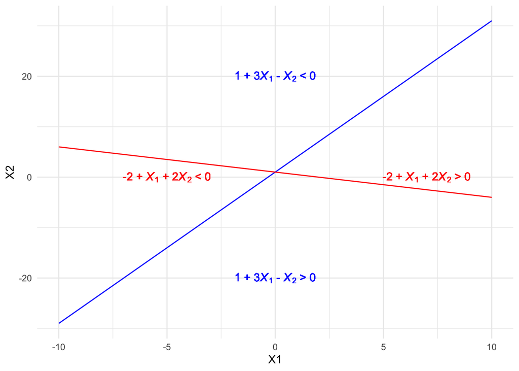

```r
library(ggplot2)

# line in a)
df <- data.frame(x1 = -10:10, x2 = 1 + 3 * (-10:10))
# line in b)
df2 <- data.frame(x1 = -10:10, x2 = 1 - 1/2 * (-10:10))

ggplot(df, aes(x = x1, y = x2)) +
  geom_line(color = "blue") +
  # Add math expressions
  geom_text(aes(x = 0, y = -20), label ="paste('1 + 3', italic(X[1]), ' - ', italic(X[2]), ' > 0')", color = "blue", parse = TRUE) +
  geom_text(aes(x = 0, y = 20), label = "paste('1 + 3', italic(X[1]), ' - ', italic(X[2]), ' < 0')", color = "blue", parse = TRUE) +
  theme_minimal() +
  labs(x = "X1", y = "X2") +
  geom_line(data = df2, aes(x = x1, y = x2), color = "red") +
  geom_text(data = df2, aes(x = -5, y = 0), label = "paste('-2 + ', italic(X[1]), ' + 2', italic(X[2]), ' < 0')", color = "red", parse = TRUE) +
  geom_text(data = df2, aes(x = 7, y = 0), label = "paste('-2 + ', italic(X[1]), ' + 2', italic(X[2]), ' > 0')", color = "red", parse = TRUE)
```

## 2 ISL Exercise 9.7.2 (10pts)

We have seen that in p = 2 dimensions, a linear decision boundary takes the form $\beta_0 +\beta_1X_1 +\beta_2X_2 = 0$. We now investigate a non-linear decision boundary.

**(a)** Sketch the curve

$(1+X_1)^2 + (2−X_2)^2 = 4$

**Answer:**

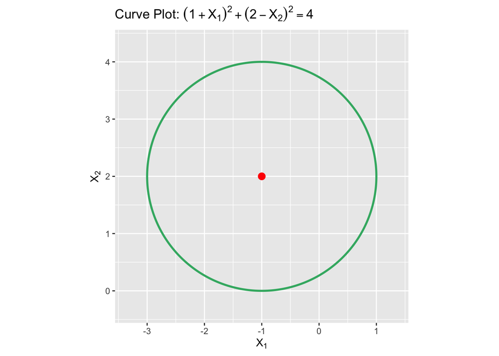

```r
library(ggplot2)
library(dplyr)
# install.packages("ggforce")
library(ggforce)
# install.packages("latex2exp")
library(latex2exp)
ggplot() +
  geom_circle(data = data.frame(X1 = -1, X2 = 2, r = 2),
              aes(x0 = X1, y0 = X2, r = r), col = "mediumseagreen", size = 1) +
  scale_x_continuous(expand = c(0.01,0.01), limits = c(-3.5, 1.5)) +
  scale_y_continuous(expand = c(0.01,0.01), limits = c(-0.5, 4.5)) +
  labs(title = TeX(r'(Curve Plot: $(1 + X_1)^2 + (2 - X_2)^2 = 4$)'),
       x = TeX(r'($X_1$)'),
       y = TeX(r'($X_2$)')) +
  coord_fixed() +
  geom_point(data = data.frame(X1 = -1, X2 = 2), aes(x = X1, y = X2), col = "red", size = 3)
```

**(b)** On your sketch, indicate the set of points for which

$(1+X_1)^2 + (2−X_2)^2 > 4$

as well as the set of points for which

$(1+X_1)^2 + (2−X_2)^2 < 4$

**Answer:**

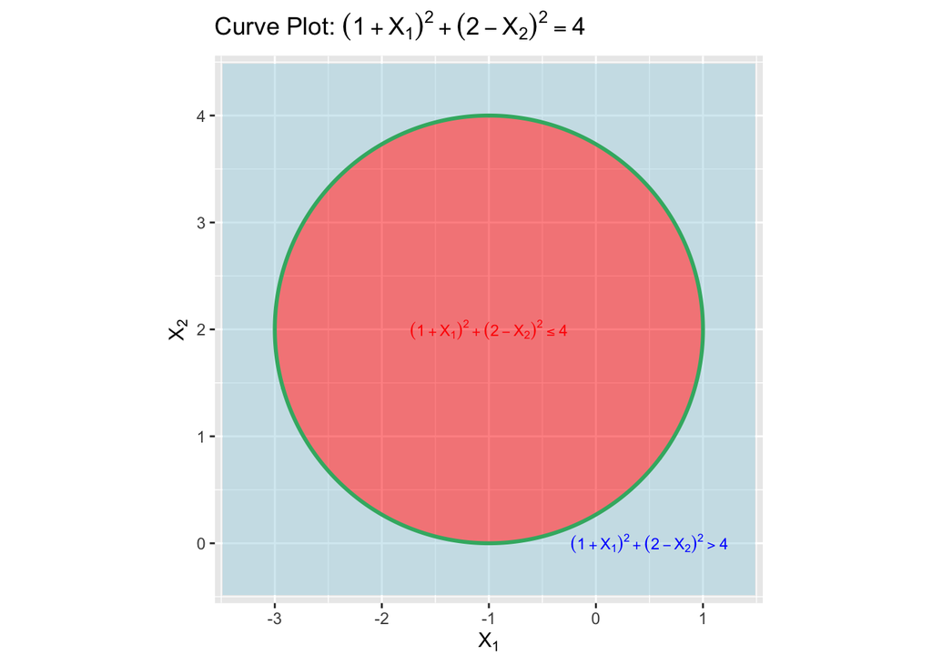

```r
grid <- expand.grid(X1 = seq(-3.5, 1.5, length.out = 200),
                    X2 = seq(-0.5, 4.5, length.out = 200)) %>%
  mutate(region = case_when((1 + X1)^2 + (2 - X2)^2 > 4 ~ "gt 4",
                            TRUE ~ "le 4"))

ggplot() +
  geom_tile(data = grid, aes(x = X1, y = X2, fill = region), alpha = 0.5) +
  geom_circle(data = data.frame(X1 = -1, X2 = 2, r = 2),
              aes(x0 = X1, y0 = X2, r = r), col = "mediumseagreen", size = 1) +
  annotate("text", x = -1, y = 2, label = TeX("$(1 + X_1)^2 + (2 - X_2)^2 \\leq 4$", output = "character"),
           hjust = 0.5, size = 3, parse = TRUE, col = "red") +
  annotate("text", x = 0.5, y = 0, label = TeX("$(1 + X_1)^2 + (2 - X_2)^2 > 4$", output = "character"),
           hjust = 0.5, size = 3, parse = TRUE, col = "blue") +
  scale_x_continuous(expand = c(0.01,0.01), limits = c(-3.5, 1.5)) +
  scale_y_continuous(expand = c(0.01,0.01), limits = c(-0.5, 4.5)) +
    scale_fill_manual(values = c("lightblue", "red")) +
  theme(legend.position = "none") +
  labs(title = TeX(r'(Curve Plot: $(1 + X_1)^2 + (2 - X_2)^2 = 4$)'),
       x = TeX(r'($X_1$)'),
       y = TeX(r'($X_2$)')) +
  coord_fixed()
```

**(c)** Suppose that a classifier assigns an observation to the blue class if

$(1+X_1)^2 + (2−X_2)^2 > 4$

and to the red class otherwise. To what class is the observation $(0, 0)$ classified? $(-1, 1)$? $(2, 2)$? $(3, 8)$?

**Answer:**

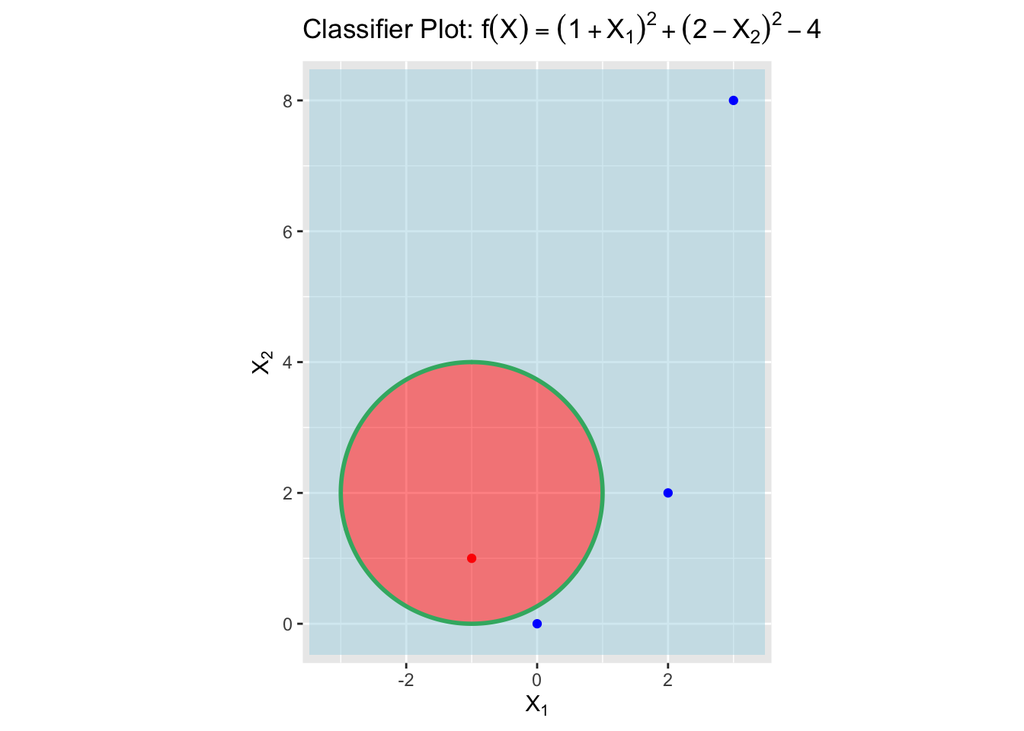

```r
new_obs <- data.frame(X1 = c(0, -1, 2, 3), X2 = c(0, 1, 2, 8)) %>%
  mutate(region = case_when((1 + X1)^2 + (2 - X2)^2 > 4 ~ "gt 4",
                            TRUE ~ "le 4"))


grid <- expand.grid(X1 = seq(-3.5, 3.5, length.out = 200),
                    X2 = seq(-0.5, 8.5, length.out = 200)) %>%
  mutate(region = case_when((1 + X1)^2 + (2 - X2)^2 > 4 ~ "gt 4",
                            TRUE ~ "le 4"))

ggplot() +
  geom_tile(data = grid, aes(x = X1, y = X2, fill = region), alpha = 0.5) +
  geom_circle(data = data.frame(X1 = -1, X2 = 2, r = 2),
              aes(x0 = X1, y0 = X2, r = r), col = "mediumseagreen", size = 1) +
  geom_point(data = new_obs, aes(x = X1, y = X2, col = region)) +
  scale_x_continuous(expand = c(0.01,0.01), limits = c(-3.5, 3.5)) +
  scale_y_continuous(expand = c(0.01,0.01), limits = c(-0.5, 8.5)) +
  scale_fill_manual(values = c("lightblue", "red")) +
  scale_color_manual(values = c("blue", "red")) +
  theme(legend.position = "none") +
  labs(title = TeX(r'(Classifier Plot: $f(X) = (1 + X_1)^2 + (2 - X_2)^2 - 4$)'),
       x = TeX(r'($X_1$)'),
       y = TeX(r'($X_2$)')) +
    coord_fixed()
```

Base on the plot, we can see that:

- $(0, 0)$: The point is outside the circle, so it is classified as blue.
- $(-1, 1)$: The point is inside the circle, so it is classified as red.
- $(2, 2)$: The point is outside the circle, so it is classified as blue.
- $(3, 8)$: The point is outside the circle, so it is classified as blue.

**(d)** Argue that while the decision boundary in (c) is not linear in terms of X1 and X2, it is linear in terms of $X_1$, $X_1^2$, $X_2$, and $X_2^2$.

**Answer:**

The decision boundary is the boundary described by $f(X)=0$:

$$\begin{align*}
f(X) &= 0 \\
\Rightarrow f(X) &= (1 + X_1)^2 + (2 - X_2)^2 - 4 \\
&= X_1^2 + 2X_1 + 1 + X_2^2 - 4X_2 + 4 - 4 \\
&= 1 + X_1^2 + 2X_1 + X_2^2 - 4X_2 \\
&= \beta_0 + \beta_1Z_1 + \beta_2Z_1 + \beta_3Z + \beta_4Z_2
\end{align*}$$

Therefore, the decision boundary is linear in terms of $X_1$, $X_1^2$, $X_2$, and $X_2^2$.

## 3 Support vector machines (SVMs) on the `Carseats` data set (30pts)

Follow the machine learning workflow to train support vector classifier (same as SVM with linear kernel), SVM with polynomial kernel (tune the degree and regularization parameter $C$), and SVM with radial kernel (tune the scale parameter $\gamma$ and regularization parameter $C$) for classifying `Sales<=8` versus `Sales>8`. Use the same seed as in your HW4 for the initial test/train split and compare the final test AUC and accuracy to those methods you tried in HW4.

**Answer:**

**SVM with polynomial kernel**

**Carseats dataset:**

```r
# Load libraries
library(GGally)
library(gtsummary)
library(kernlab)
library(tidyverse)
library(tidymodels)
library(ISLR2)
library(ggplot2)
```

```r
data(Carseats)
```

```r
Carseats <- Carseats %>% filter(!is.na(Sales)) %>%
  mutate(Sales = ifelse(Sales <= 8, "Low", "High")) %>%
  print(width = 200)
```

```
    Sales CompPrice Income Advertising Population Price ShelveLoc Age Education Urban  US
1    High       138     73          11        276   120       Bad  42        17   Yes Yes
2    High       111     48          16        260    83      Good  65        10   Yes Yes
3    High       113     35          10        269    80    Medium  59        12   Yes Yes
4     Low       117    100           4        466    97    Medium  55        14   Yes Yes
5     Low       141     64           3        340   128       Bad  38        13   Yes  No
6    High       124    113          13        501    72       Bad  78        16    No Yes
7     Low       115    105           0         45   108    Medium  71        15   Yes  No
8    High       136     81          15        425   120      Good  67        10   Yes Yes
9     Low       132    110           0        108   124    Medium  76        10    No  No
10    Low       132    113           0        131   124    Medium  76        17    No Yes
11   High       121     78           9        150   100       Bad  26        10    No Yes
12   High       117     94           4        503    94      Good  50        13   Yes Yes
13    Low       122     35           2        393   136    Medium  62        18   Yes  No
14   High       115     28          11         29    86      Good  53        18   Yes Yes
```

[output cut: 386 more lines]

```r
Carseats %>% tbl_summary(by = Sales)
```

| **Characteristic** | **High**, N = 164<sup>1</sup> | **Low**, N = 236<sup>1</sup> |
| --- | --- | --- |
| CompPrice | 127 (115, 136) | 124 (115, 134) |
| Income | 76 (58, 94) | 65 (40, 88) |
| Advertising | 10.0 (0.0, 14.0) | 3.0 (0.0, 10.0) |
| Population | 276 (150, 403) | 268 (132, 389) |
| Price | 107 (90, 123) | 122 (107, 135) |
| ShelveLoc |  |  |
| Bad | 14 (8.5%) | 82 (35%) |
| Good | 66 (40%) | 19 (8.1%) |
| Medium | 84 (51%) | 135 (57%) |
| Age | 49 (36, 61) | 58 (42, 70) |
| Education |  |  |
| 10 | 25 (15%) | 23 (9.7%) |
| 11 | 17 (10%) | 31 (13%) |
| 12 | 19 (12%) | 30 (13%) |
| 13 | 17 (10%) | 26 (11%) |
| 14 | 14 (8.5%) | 26 (11%) |
| 15 | 18 (11%) | 18 (7.6%) |
| 16 | 18 (11%) | 29 (12%) |
| 17 | 21 (13%) | 28 (12%) |
| 18 | 15 (9.1%) | 25 (11%) |
| Urban | 110 (67%) | 172 (73%) |
| US | 123 (75%) | 135 (57%) |

<sup>1</sup> Median (IQR); n (%)

**Initial split into test and non-test sets:**

```r
# For reproducibility
set.seed(212)

data_split <- initial_split(
  Carseats,
  prop = 0.5,
  strata = Sales
  )
data_split
```

```
<Training/Testing/Total>
<200/200/400>
```

```r
Carseats_other <- training(data_split)
dim(Carseats_other)
```

```
[1] 200  11
```

```r
Carseats_test <- testing(data_split)
dim(Carseats_test)
```

```
[1] 200  11
```

**Recipe:**

```r
svm_recipe <-
  recipe(
    Sales ~ .,
    data = Carseats_other
  ) %>%
  step_naomit(all_predictors()) %>%
  # # create traditional dummy variables (not necessary for random forest in R)
  step_dummy(all_nominal_predictors()) %>%
  # zero-variance filter
  step_zv(all_numeric_predictors()) %>%
  # # center and scale numeric data (not necessary for random forest)
  step_normalize(all_numeric_predictors()) %>%
  # estimate the means and standard deviations
  prep(training = Carseats_other, retain = TRUE)
svm_recipe
```

**Model:**

```r
svm_poly_mod <-
  # specify the model
  svm_poly(
    mode = "classification",
    cost = tune(),
    degree = tune(),
    # scale_factor = tune()
  ) %>%
  set_engine("kernlab")
svm_poly_mod
```

```
Polynomial Support Vector Machine Model Specification (classification)

Main Arguments:
  cost = tune()
  degree = tune()

Computational engine: kernlab
```

**Workflow:**

```r
svm_poly_wf <- workflow() %>%
  add_recipe(svm_recipe) %>%
  add_model(svm_poly_mod)
svm_poly_wf
```

```
══ Workflow ════════════════════════════════════════════════════════════════════
Preprocessor: Recipe
Model: svm_poly()

── Preprocessor ────────────────────────────────────────────────────────────────
4 Recipe Steps

• step_naomit()
• step_dummy()
• step_zv()
• step_normalize()

── Model ───────────────────────────────────────────────────────────────────────
Polynomial Support Vector Machine Model Specification (classification)

Main Arguments:
  cost = tune()
  degree = tune()

Computational engine: kernlab
```

**Tuning grid:**

```r
param_grid <- grid_regular(
  cost(range = c(-3, 2)),
  degree(range = c(1, 5)),
  #scale_factor(range = c(-1, 1)),
  levels = c(5)
  )
param_grid
```

```
# A tibble: 25 × 2
    cost degree
   <dbl>  <dbl>
 1 0.125      1
 2 0.297      1
 3 0.707      1
 4 1.68       1
 5 4          1
 6 0.125      2
 7 0.297      2
 8 0.707      2
 9 1.68       2
10 4          2
# ℹ 15 more rows
```

**Cross-validation:**

```r
set.seed(212)

folds <- vfold_cv(Carseats_other, v = 5)
folds
```

```
#  5-fold cross-validation
# A tibble: 5 × 2
  splits           id
  <list>           <chr>
1 <split [160/40]> Fold1
2 <split [160/40]> Fold2
3 <split [160/40]> Fold3
4 <split [160/40]> Fold4
5 <split [160/40]> Fold5
```

Fit cross-validation:

```r
svm_poly_fit <- svm_poly_wf %>%
  tune_grid(
    resamples = folds,
    grid = param_grid,
    metrics = metric_set(roc_auc, accuracy)
    )
svm_poly_fit
```

```
# Tuning results
# 5-fold cross-validation
# A tibble: 5 × 4
  splits           id    .metrics          .notes
  <list>           <chr> <list>            <list>
1 <split [160/40]> Fold1 <tibble [50 × 6]> <tibble [0 × 3]>
2 <split [160/40]> Fold2 <tibble [50 × 6]> <tibble [0 × 3]>
3 <split [160/40]> Fold3 <tibble [50 × 6]> <tibble [0 × 3]>
4 <split [160/40]> Fold4 <tibble [50 × 6]> <tibble [0 × 3]>
5 <split [160/40]> Fold5 <tibble [50 × 6]> <tibble [0 × 3]>
```

Visualize CV results:

```
# A tibble: 50 × 8
    cost degree .metric  .estimator  mean     n std_err .config
   <dbl>  <dbl> <chr>    <chr>      <dbl> <int>   <dbl> <chr>
 1 0.125      1 accuracy binary     0.855     5 0.0146  Preprocessor1_Model01
 2 0.125      1 roc_auc  binary     0.931     5 0.0135  Preprocessor1_Model01
 3 0.297      1 accuracy binary     0.855     5 0.0166  Preprocessor1_Model02
 4 0.297      1 roc_auc  binary     0.943     5 0.0120  Preprocessor1_Model02
 5 0.707      1 accuracy binary     0.845     5 0.0122  Preprocessor1_Model03
 6 0.707      1 roc_auc  binary     0.939     5 0.0155  Preprocessor1_Model03
 7 1.68       1 accuracy binary     0.845     5 0.0146  Preprocessor1_Model04
 8 1.68       1 roc_auc  binary     0.939     5 0.0158  Preprocessor1_Model04
 9 4          1 accuracy binary     0.845     5 0.00500 Preprocessor1_Model05
10 4          1 roc_auc  binary     0.942     5 0.0154  Preprocessor1_Model05
# ℹ 40 more rows
```

[figure not shown]

```r
svm_poly_fit %>%
  collect_metrics() %>%
  print(width = Inf) %>%
  filter(.metric == "roc_auc" ) %>%
  ggplot(mapping = aes(x = degree, y = mean)) +
  geom_point() +
  geom_line() +
  labs(x = "Cost", y = "CV AUC") +
  scale_x_log10()
```

Show the top 5 models:

```r
svm_poly_fit %>%
  show_best("roc_auc")
```

```
# A tibble: 5 × 8
   cost degree .metric .estimator  mean     n std_err .config
  <dbl>  <dbl> <chr>   <chr>      <dbl> <int>   <dbl> <chr>
1 0.297      1 roc_auc binary     0.943     5  0.0120 Preprocessor1_Model02
2 4          1 roc_auc binary     0.942     5  0.0154 Preprocessor1_Model05
3 0.707      1 roc_auc binary     0.939     5  0.0155 Preprocessor1_Model03
4 1.68       1 roc_auc binary     0.939     5  0.0158 Preprocessor1_Model04
5 0.125      1 roc_auc binary     0.931     5  0.0135 Preprocessor1_Model01
```

Select the best model:

```r
best_svm_poly <- svm_poly_fit %>%
  select_best("roc_auc")
best_svm_poly
```

```
# A tibble: 1 × 3
   cost degree .config
  <dbl>  <dbl> <chr>
1 0.297      1 Preprocessor1_Model02
```

**Finalize our model:**

```r
# Final workflow
final_poly_wf <- svm_poly_wf %>%
  finalize_workflow(best_svm_poly)
final_poly_wf
```

```
══ Workflow ════════════════════════════════════════════════════════════════════
Preprocessor: Recipe
Model: svm_poly()

── Preprocessor ────────────────────────────────────────────────────────────────
4 Recipe Steps

• step_naomit()
• step_dummy()
• step_zv()
• step_normalize()

── Model ───────────────────────────────────────────────────────────────────────
Polynomial Support Vector Machine Model Specification (classification)

Main Arguments:
  cost = 0.29730177875068
  degree = 1

Computational engine: kernlab
```

```r
# Fit the whole training set, then predict the test cases
final_poly_fit <-
  final_poly_wf %>%
  last_fit(data_split)
final_poly_fit
```

```
# Resampling results
# Manual resampling
# A tibble: 1 × 6
  splits            id               .metrics .notes   .predictions .workflow
  <list>            <chr>            <list>   <list>   <list>       <list>
1 <split [200/200]> train/test split <tibble> <tibble> <tibble>     <workflow>
```

```r
# Test metrics
final_poly_fit %>%
  collect_metrics()
```

```
# A tibble: 2 × 4
  .metric  .estimator .estimate .config
  <chr>    <chr>          <dbl> <chr>
1 accuracy binary         0.865 Preprocessor1_Model1
2 roc_auc  binary         0.965 Preprocessor1_Model1
```

```r
test_roc_auc_poly <- final_poly_fit %>%
  collect_metrics() %>%
  filter(.metric == "roc_auc") %>%
  pull(.estimate)
test_roc_auc_poly
```

```
[1] 0.9652749
```

```r
test_accuracy_poly <- final_poly_fit %>%
  collect_metrics() %>%
  filter(.metric == "accuracy") %>%
  pull(.estimate)
test_accuracy_poly
```

```
[1] 0.865
```

**SVM with radial kernel**

**Model:**

```r
svm_radial_mod <-
  # specify the model
  svm_rbf(
    mode = "classification",
    cost = tune(),
    rbf_sigma = tune()
  ) %>%
  set_engine("kernlab")
svm_radial_mod
```

```
Radial Basis Function Support Vector Machine Model Specification (classification)

Main Arguments:
  cost = tune()
  rbf_sigma = tune()

Computational engine: kernlab
```

**Workflow:**

```r
svm_radial_wf <- workflow() %>%
  add_recipe(svm_recipe) %>%
  add_model(svm_radial_mod)
svm_radial_wf
```

```
══ Workflow ════════════════════════════════════════════════════════════════════
Preprocessor: Recipe
Model: svm_rbf()

── Preprocessor ────────────────────────────────────────────────────────────────
4 Recipe Steps

• step_naomit()
• step_dummy()
• step_zv()
• step_normalize()

── Model ───────────────────────────────────────────────────────────────────────
Radial Basis Function Support Vector Machine Model Specification (classification)

Main Arguments:
  cost = tune()
  rbf_sigma = tune()

Computational engine: kernlab
```

**Tuning grid:**

```r
param_grid_radial <- grid_regular(
  cost(range = c(-8, 5)),
  rbf_sigma(range = c(-5, -3)),
  levels = c(14, 5)
  )
param_grid_radial
```

```
# A tibble: 70 × 2
      cost rbf_sigma
     <dbl>     <dbl>
 1 0.00391   0.00001
 2 0.00781   0.00001
 3 0.0156    0.00001
 4 0.0312    0.00001
 5 0.0625    0.00001
 6 0.125     0.00001
 7 0.25      0.00001
 8 0.5       0.00001
 9 1         0.00001
10 2         0.00001
# ℹ 60 more rows
```

**Cross-validation:**

```r
set.seed(212)

folds <- vfold_cv(Carseats_other, v = 5)
folds
```

```
#  5-fold cross-validation
# A tibble: 5 × 2
  splits           id
  <list>           <chr>
1 <split [160/40]> Fold1
2 <split [160/40]> Fold2
3 <split [160/40]> Fold3
4 <split [160/40]> Fold4
5 <split [160/40]> Fold5
```

Fit cross-validation:

```r
svm_radial_fit <- svm_radial_wf %>%
  tune_grid(
    resamples = folds,
    grid = param_grid_radial,
    metrics = metric_set(roc_auc, accuracy)
    )
svm_radial_fit
```

```
# Tuning results
# 5-fold cross-validation
# A tibble: 5 × 4
  splits           id    .metrics           .notes
  <list>           <chr> <list>             <list>
1 <split [160/40]> Fold1 <tibble [140 × 6]> <tibble [0 × 3]>
2 <split [160/40]> Fold2 <tibble [140 × 6]> <tibble [0 × 3]>
3 <split [160/40]> Fold3 <tibble [140 × 6]> <tibble [0 × 3]>
4 <split [160/40]> Fold4 <tibble [140 × 6]> <tibble [0 × 3]>
5 <split [160/40]> Fold5 <tibble [140 × 6]> <tibble [0 × 3]>
```

Visualize CV results:

```
# A tibble: 140 × 8
      cost rbf_sigma .metric  .estimator  mean     n std_err
     <dbl>     <dbl> <chr>    <chr>      <dbl> <int>   <dbl>
 1 0.00391   0.00001 accuracy binary     0.59      5  0.0100
 2 0.00391   0.00001 roc_auc  binary     0.855     5  0.0295
 3 0.00781   0.00001 accuracy binary     0.59      5  0.0100
 4 0.00781   0.00001 roc_auc  binary     0.855     5  0.0295
 5 0.0156    0.00001 accuracy binary     0.59      5  0.0100
 6 0.0156    0.00001 roc_auc  binary     0.855     5  0.0295
 7 0.0312    0.00001 accuracy binary     0.59      5  0.0100
 8 0.0312    0.00001 roc_auc  binary     0.855     5  0.0295
 9 0.0625    0.00001 accuracy binary     0.59      5  0.0100
10 0.0625    0.00001 roc_auc  binary     0.855     5  0.0295
   .config
   <chr>
 1 Preprocessor1_Model01
 2 Preprocessor1_Model01
 3 Preprocessor1_Model02
 4 Preprocessor1_Model02
 5 Preprocessor1_Model03
 6 Preprocessor1_Model03
 7 Preprocessor1_Model04
 8 Preprocessor1_Model04
 9 Preprocessor1_Model05
10 Preprocessor1_Model05
# ℹ 130 more rows
```

[figure not shown]

```r
svm_radial_fit %>%
  collect_metrics() %>%
  print(width = Inf) %>%
  filter(.metric == "roc_auc" ) %>%
  ggplot(mapping = aes(x = rbf_sigma, y = mean)) +
  geom_point() +
  geom_line() +
  labs(x = "Cost", y = "CV AUC") +
  scale_x_log10()
```

Show the top 5 models:

```r
svm_radial_fit %>%
  show_best("roc_auc")
```

```
# A tibble: 5 × 8
   cost rbf_sigma .metric .estimator  mean     n std_err .config
  <dbl>     <dbl> <chr>   <chr>      <dbl> <int>   <dbl> <chr>
1    32  0.001    roc_auc binary     0.919     5  0.0156 Preprocessor1_Model70
2    16  0.001    roc_auc binary     0.902     5  0.0143 Preprocessor1_Model69
3    32  0.000316 roc_auc binary     0.895     5  0.0171 Preprocessor1_Model56
4     8  0.001    roc_auc binary     0.886     5  0.0205 Preprocessor1_Model68
5    16  0.000316 roc_auc binary     0.872     5  0.0234 Preprocessor1_Model55
```

Select the best model:

```r
best_svm_radial <- svm_radial_fit %>%
  select_best("roc_auc")
```

**Finalize our model:**

```r
# Final workflow
final_radial_wf <- svm_radial_wf %>%
  finalize_workflow(best_svm_radial)
```

```r
# Fit the whole training set, then predict the test cases
final_radial_fit <-
  final_radial_wf %>%
  last_fit(data_split)
```

```r
# Test metrics
final_radial_fit %>%
  collect_metrics()
```

```
# A tibble: 2 × 4
  .metric  .estimator .estimate .config
  <chr>    <chr>          <dbl> <chr>
1 accuracy binary         0.845 Preprocessor1_Model1
2 roc_auc  binary         0.950 Preprocessor1_Model1
```

```r
test_roc_auc_radial <- final_radial_fit %>%
  collect_metrics() %>%
  filter(.metric == "roc_auc") %>%
  pull(.estimate)
test_roc_auc_radial
```

```
[1] 0.9502894
```

```r
test_accuracy_radial <- final_radial_fit %>%
  collect_metrics() %>%
  filter(.metric == "accuracy") %>%
  pull(.estimate)
test_accuracy_radial
```

```
[1] 0.845
```

**SVM with linear kernel**

**Model:**

```r
svm_linear_mod <-
  # specify the model
  svm_linear(
    mode = "classification",
    cost = tune()
  ) %>%
  set_engine("kernlab")
```

**Workflow:**

```r
svm_linear_wf <- workflow() %>%
  add_recipe(svm_recipe) %>%
  add_model(svm_linear_mod)
```

**Tuning grid:**

```r
param_grid_linear <- grid_regular(
  cost(range = c(-3, 2)),
  levels = c(5)
  )
param_grid_linear
```

```
# A tibble: 5 × 1
   cost
  <dbl>
1 0.125
2 0.297
3 0.707
4 1.68
5 4
```

**Cross-validation:**

```r
set.seed(212)

folds <- vfold_cv(Carseats_other, v = 5)
folds
```

```
#  5-fold cross-validation
# A tibble: 5 × 2
  splits           id
  <list>           <chr>
1 <split [160/40]> Fold1
2 <split [160/40]> Fold2
3 <split [160/40]> Fold3
4 <split [160/40]> Fold4
5 <split [160/40]> Fold5
```

Fit cross-validation:

```r
svm_linear_fit <- svm_linear_wf %>%
  tune_grid(
    resamples = folds,
    grid = param_grid_linear,
    metrics = metric_set(roc_auc, accuracy)
    )
```

Visualize CV results:

```
# A tibble: 10 × 7
    cost .metric  .estimator  mean     n std_err .config
   <dbl> <chr>    <chr>      <dbl> <int>   <dbl> <chr>
 1 0.125 accuracy binary     0.855     5 0.0146  Preprocessor1_Model1
 2 0.125 roc_auc  binary     0.931     5 0.0135  Preprocessor1_Model1
 3 0.297 accuracy binary     0.855     5 0.0166  Preprocessor1_Model2
 4 0.297 roc_auc  binary     0.943     5 0.0120  Preprocessor1_Model2
 5 0.707 accuracy binary     0.845     5 0.0122  Preprocessor1_Model3
 6 0.707 roc_auc  binary     0.939     5 0.0155  Preprocessor1_Model3
 7 1.68  accuracy binary     0.845     5 0.0146  Preprocessor1_Model4
 8 1.68  roc_auc  binary     0.939     5 0.0158  Preprocessor1_Model4
 9 4     accuracy binary     0.845     5 0.00500 Preprocessor1_Model5
10 4     roc_auc  binary     0.942     5 0.0154  Preprocessor1_Model5
```

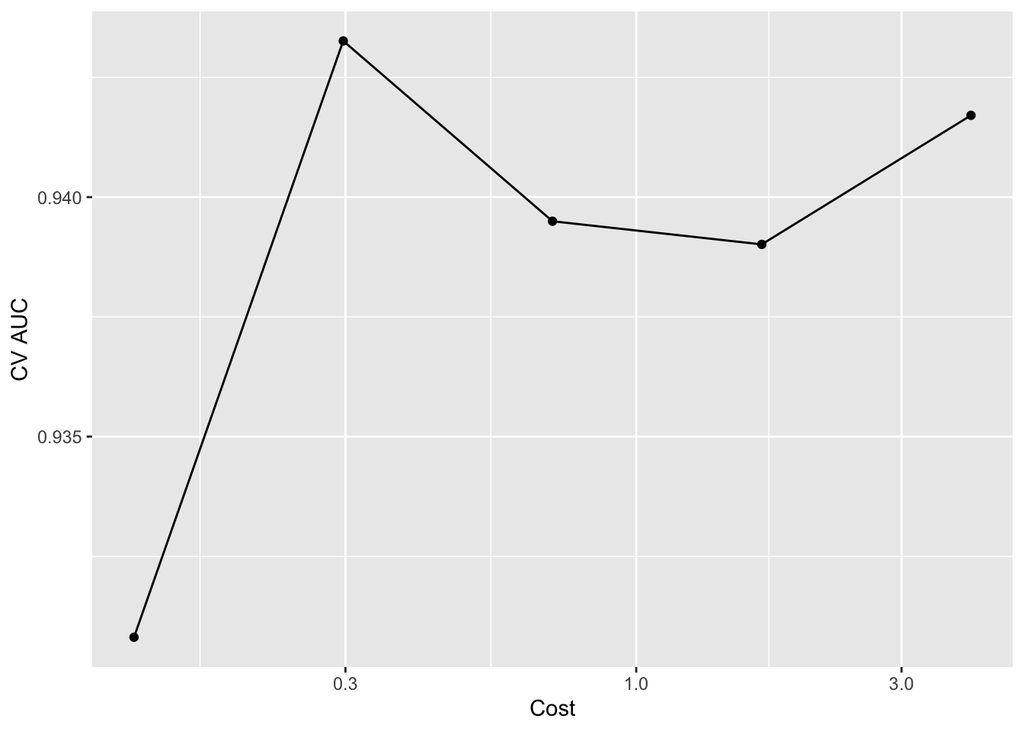

```r
svm_linear_fit %>%
  collect_metrics() %>%
  print(width = Inf) %>%
  filter(.metric == "roc_auc" ) %>%
  ggplot(mapping = aes(x = cost, y = mean)) +
  geom_point() +
  geom_line() +
  labs(x = "Cost", y = "CV AUC") +
  scale_x_log10()
```

Show the top 5 models:

```r
svm_linear_fit %>%
  show_best("roc_auc")
```

```
# A tibble: 5 × 7
   cost .metric .estimator  mean     n std_err .config
  <dbl> <chr>   <chr>      <dbl> <int>   <dbl> <chr>
1 0.297 roc_auc binary     0.943     5  0.0120 Preprocessor1_Model2
2 4     roc_auc binary     0.942     5  0.0154 Preprocessor1_Model5
3 0.707 roc_auc binary     0.939     5  0.0155 Preprocessor1_Model3
4 1.68  roc_auc binary     0.939     5  0.0158 Preprocessor1_Model4
5 0.125 roc_auc binary     0.931     5  0.0135 Preprocessor1_Model1
```

Select the best model:

```r
best_svm_linear <- svm_linear_fit %>%
  select_best("roc_auc")
```

**Finalize our model:**

```r
# Final workflow
final_linear_wf <- svm_linear_wf %>%
  finalize_workflow(best_svm_linear)
final_linear_wf
```

```
══ Workflow ════════════════════════════════════════════════════════════════════
Preprocessor: Recipe
Model: svm_linear()

── Preprocessor ────────────────────────────────────────────────────────────────
4 Recipe Steps

• step_naomit()
• step_dummy()
• step_zv()
• step_normalize()

── Model ───────────────────────────────────────────────────────────────────────
Linear Support Vector Machine Model Specification (classification)

Main Arguments:
  cost = 0.29730177875068

Computational engine: kernlab
```

```r
# Fit the whole training set, then predict the test cases
final_linear_fit <-
  final_linear_wf %>%
  last_fit(data_split)
```

```r
# Test metrics
final_linear_fit %>%
  collect_metrics()
```

```
# A tibble: 2 × 4
  .metric  .estimator .estimate .config
  <chr>    <chr>          <dbl> <chr>
1 accuracy binary         0.865 Preprocessor1_Model1
2 roc_auc  binary         0.965 Preprocessor1_Model1
```

```r
test_roc_auc_linear <- final_linear_fit %>%
  collect_metrics() %>%
  filter(.metric == "roc_auc") %>%
  pull(.estimate)
test_roc_auc_linear
```

```
[1] 0.9652749
```

```r
test_accuracy_linear <- final_linear_fit %>%
  collect_metrics() %>%
  filter(.metric == "accuracy") %>%
  pull(.estimate)
test_accuracy_linear
```

```
[1] 0.865
```

Compare the final test AUC and accuracy to those methods you tried in HW4.

```r
# Create a tibble to store the results
results_df <- tibble(
  Model = c("SVM with polynomial kernel", "SVM with radial kernel", "SVM with linear kernel", "Classification Tree", "Random Forest", "Boosting"),
  test_ROC_AUC = c(test_roc_auc_poly, test_roc_auc_radial, test_roc_auc_linear, 0.760 , 0.874, 0.918),
  test_Accuracy = c(test_accuracy_poly, test_accuracy_radial, test_accuracy_linear, 0.755, 0.78, 0.845)
)

# Print the final results
print(results_df)
```

```
# A tibble: 6 × 3
  Model                      test_ROC_AUC test_Accuracy
  <chr>                             <dbl>         <dbl>
1 SVM with polynomial kernel        0.965         0.865
2 SVM with radial kernel            0.950         0.845
3 SVM with linear kernel            0.965         0.865
4 Classification Tree               0.76          0.755
5 Random Forest                     0.874         0.78
6 Boosting                          0.918         0.845
```

## 4 Bonus (10pts)

Let

$$f(X) = \beta_0 + \beta_1 X_1 + \cdots + \beta_p X_p = \beta_0 + \beta^T X$$

Then $f(X)=0$ defines a hyperplane in $\mathbb{R}^p$. Show that $f(x)$ is proportional to the signed distance of a point $x$ to the hyperplane $f(X) = 0$.

**Answer:**

The plane is

$$\beta_0 + \beta_1 X_1 + \cdots + \beta_p X_p = 0$$

The vector $\beta = (\beta_1, \beta2, ..., \beta_p)$ the normal to vector. It points in a direction orthogonal to the surface of hyperplane.

Let

$$\mathbf{v} = (\beta_1, \beta_2, ..., \beta_p)$$

For any $x_0$ in the hyperplane $f(x)=0$, let

$$x_0 = (x_{01}, x_{02}, ..., x_{0p})$$

Therefore,

$$\begin{align*}
\beta_0 + \beta_1 x_{01} + \cdots + \beta_p x_{0p} = 0
\end{align*}$$

$$\Rightarrow -\beta_0 = \beta_1 x_{01} + \cdots + \beta_p x_{0p}$$

For any $x$, let

$$x = (x_1, x_2, ..., x_p)$$

The vector from $x_0$ to $x$ is

$$\mathbf{w} = (x_1 - x_{01}, x_2 - x_{02}, ..., x_p - x_{0p})$$

The the signed distance of $x$ is

$$\begin{align*}
d &= \frac{\mathbf{v} \cdot \mathbf{w}}{\|\mathbf{v}\|} \\
&= \frac{\beta_1(x_1 - x_{01}) + \beta_2(x_2 - x_{02}) + \cdots + \beta_p(x_p - x_{0p})}{\sqrt{\beta_1^2 + \beta_2^2 + \cdots + \beta_p^2}} \\
&= \frac{\beta_1x_1 + \beta_2x_2 + \cdots + \beta_px_p -
(\beta_1x_{01} + \beta_2x_{02} + \cdots + \beta_px_{0p} )}
{\sqrt{\beta_1^2 + \beta_2^2 + \cdots + \beta_p^2}} \\
&= \frac{\beta_1x_1 + \beta_2x_2 + \cdots + \beta_px_p + \beta_0 }{\|\beta\|} \\
&= \frac{\beta^T x + \beta_0}{\|\beta\|} \\
&= \frac{f(x)}{\|\beta\|} \\
\end{align*}$$

Therefore, $f(x)$ is proportional to the signed distance of a point $x$ to the hyperplane $f(X) = 0$.